# Lab: Modified Introduction To R

# 5 Base Graphics

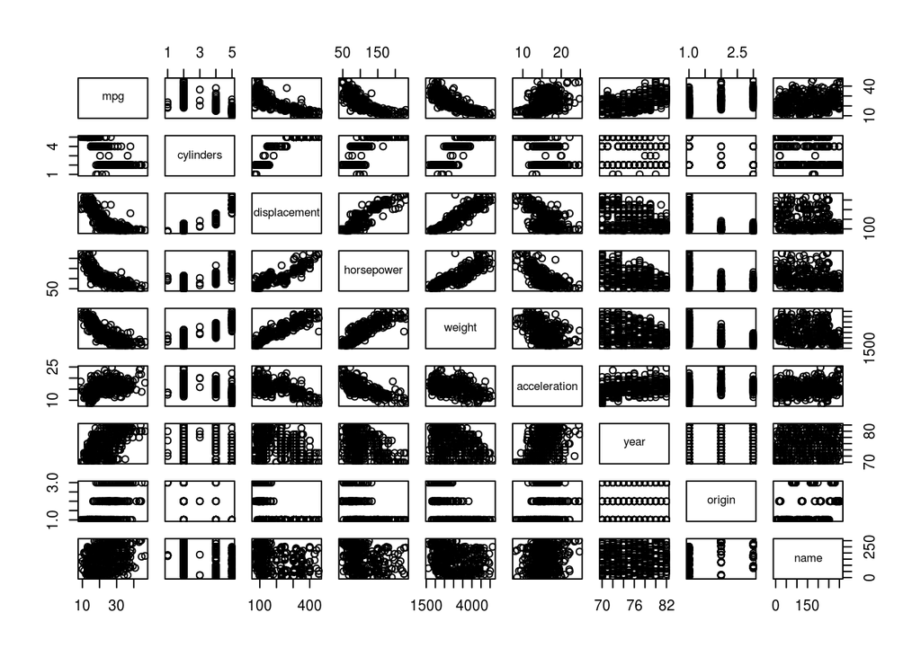

```r
pairs(Auto)
```

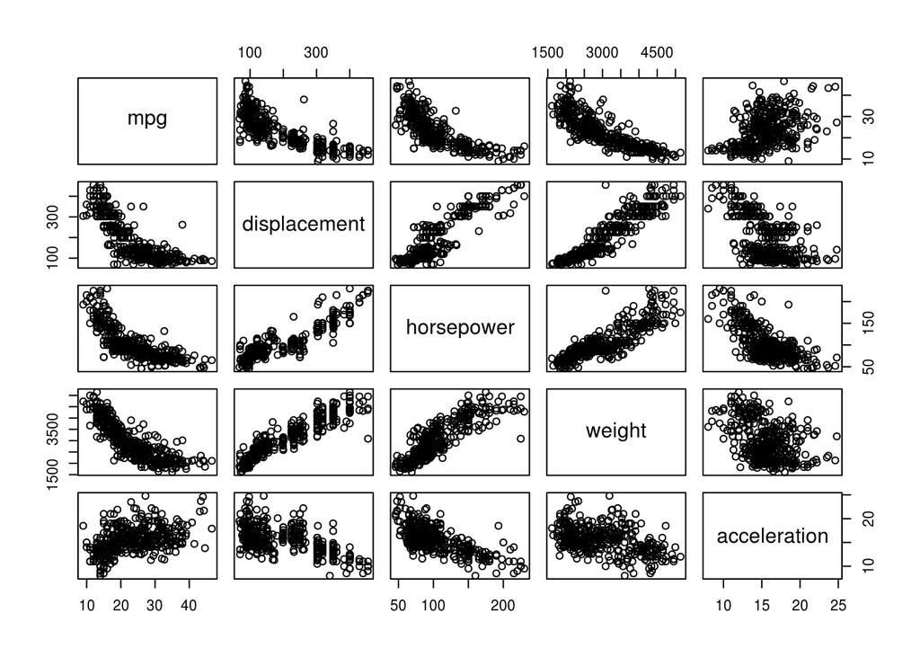

```r
pairs(~ mpg + displacement + horsepower + weight + acceleration, data = Auto)
```

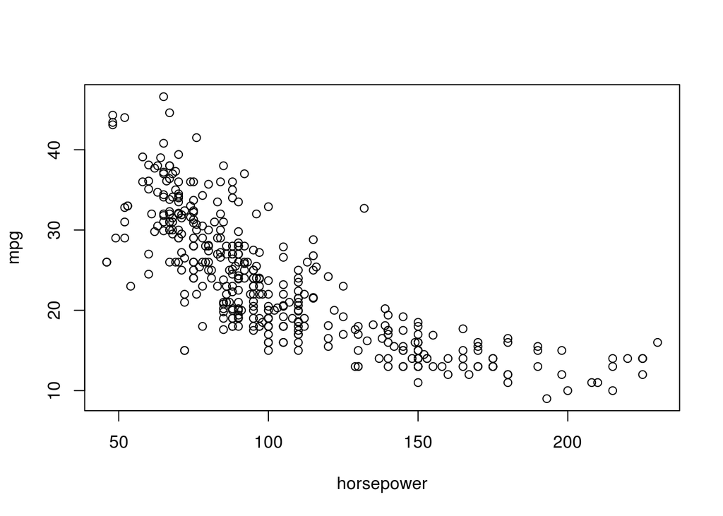

```r
plot(mpg ~ horsepower, data = Auto)
```

```r
summary(Auto)
```

```
##       mpg        cylinders  displacement     horsepower        weight
##  Min.   : 9.00   3:  4     Min.   : 68.0   Min.   : 46.0   Min.   :1613
##  1st Qu.:17.00   4:199     1st Qu.:105.0   1st Qu.: 75.0   1st Qu.:2225
##  Median :22.75   5:  3     Median :151.0   Median : 93.5   Median :2804
##  Mean   :23.45   6: 83     Mean   :194.4   Mean   :104.5   Mean   :2978
##  3rd Qu.:29.00   8:103     3rd Qu.:275.8   3rd Qu.:126.0   3rd Qu.:3615
##  Max.   :46.60             Max.   :455.0   Max.   :230.0   Max.   :5140
##
##   acceleration        year           origin                      name
##  Min.   : 8.00   Min.   :70.00   Min.   :1.000   amc matador       :  5
##  1st Qu.:13.78   1st Qu.:73.00   1st Qu.:1.000   ford pinto        :  5
##  Median :15.50   Median :76.00   Median :1.000   toyota corolla    :  5
##  Mean   :15.54   Mean   :75.98   Mean   :1.577   amc gremlin       :  4
##  3rd Qu.:17.02   3rd Qu.:79.00   3rd Qu.:2.000   amc hornet        :  4
##  Max.   :24.80   Max.   :82.00   Max.   :3.000   chevrolet chevette:  4
##                                                  (Other)           :365
```

```r
summary(Auto$mpg)
```

```
##    Min. 1st Qu.  Median    Mean 3rd Qu.    Max.
##    9.00   17.00   22.75   23.45   29.00   46.60
```

## 5.1 Refer to a plot or to an equation:

### 5.1.1 Example Problem 9.12

A bottled water company acquires its water from two independent sources, `x` and `y`. The company suspects that the sodium content in the water from source `x` is less than the sodium content for water from source `y`. An independent agency measures the sodium content in 20 samples from source `x` and 10 samples from source `y` and stores them in the data frame `WATER`. Is there statistical evidence to suggest the average sodium content in the water from source `x` is less than the average sodium content in the water from source `y`? The measurements for the sodium values are mg/L. Use an $\alpha$ of 0.05 to test the appropriate hypotheses.

### 5.1.2 Partial Solution

To solve this problem, start by verifying the reasonableness of the normality assumption. The side-by-side boxplots and normal quantile-quantile plots depicted in Figures 5.1 and 5.2, respectively suggest it is reasonable to assume the sodium values for both sources follow normal distributions; however, it is clear from the boxplots that the variances are very different.

```r
library(PASWR2)
```

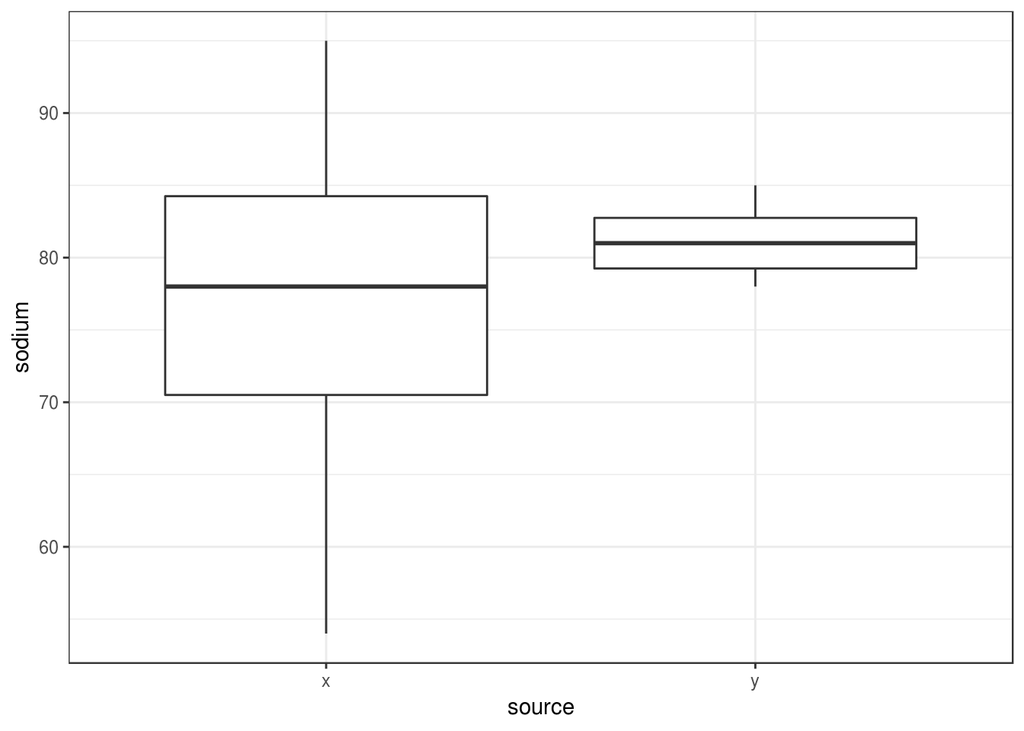

Figure 5.1: Side-by-side boxplots of the sodium content for source `x` and `y`

```r
ggplot(data = WATER, mapping = aes(x = source, y = sodium)) +
  geom_boxplot() +
  theme_bw()
```

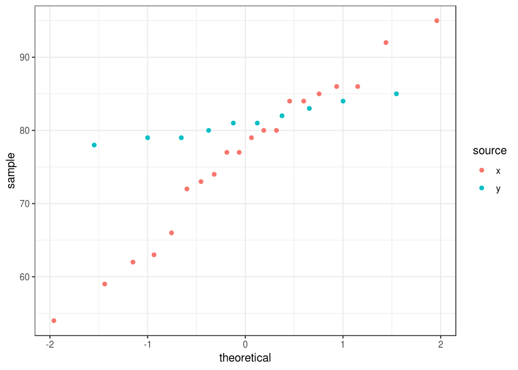

Figure 5.2: Normal quantile-quantile plots of the sodium content for source `x` and source`y`

```r
ggplot(data = WATER, mapping = aes(sample = sodium, color = source)) +
  stat_qq() +
  theme_bw()
```

Step 1: **Hypotheses** — Since the problem wants to test to see if the mean sodium content from source `x` is less than the mean sodium content from source `y`, use a lower one-sided alternative hypothesis as shown in Equation (5.1).

$$\begin{align}
H_0&: \mu_x - \mu_y = 0 \nonumber \\
H_A&: \mu_x - \mu_y < 0.
\tag{5.1}
\end{align}$$

```r
library(dplyr)
NDF <- WATER %>%
  group_by(source) %>%
  summarize(MEAN = mean(sodium), SD = sd(sodium), n = n())
knitr::kable(NDF, caption = "Summary statistics for the `WATER` data frame")
```

Table 5.1: Summary statistics for the `WATER` data frame

| source | MEAN | SD | n |
| --- | --- | --- | --- |
| x | 76.4 | 11.080566 | 20 |
| y | 81.2 | 2.299758 | 10 |

Step 2: **Test Statistic** — The test statistic chosen is $\bar{X} - \bar{Y}$ because $E\left[\bar{X} - \bar{Y} \right] = \mu_x - \mu_y$. The value of this test statistic is $76.4 - 81.2 = -4.8$. The standardized test statistic under the assumption theat $H_0$ is true and its appropriate distribution are given in Equation (5.2).

$$\begin{equation}
\frac{\left[(\bar{X} - \bar{Y}) - \delta_0 \right]}{\sqrt{\left(\frac{S_x^2}{n_x} + \frac{S_y^2}{n_y}\right)}} \overset{\bullet}{\sim} t_{\nu}
\tag{5.2}
\end{equation}$$

```r
t.test(sodium ~ source, data = WATER, alternative = "less")
```

```
##
##  Welch Two Sample t-test
##
## data:  sodium by source
## t = -1.8589, df = 22.069, p-value = 0.03822
## alternative hypothesis: true difference in means is less than 0
## 95 percent confidence interval:
##        -Inf -0.3665724
## sample estimates:
## mean in group x mean in group y
##            76.4            81.2
```

## 5.2 Automagic Generation of `R` Package References

Suppose the following `R` packages are used for a project: `DT`, `ggplot2`, `ISLR`, `knitr`, `plotly`, `dplyr`, `rmarkdown`, and `bookdown`.

1. Create an object named `PackagesUsed`.
2. Write the packages used to a `*.bib` file.
3. Load the packages with `lapply()`.
4. Add a `bibliography` entry to the YAML.
5. Cite the package using `@R-packagename` (look at the `*.bib` file for the exact name)
6. Add a `References` section header (`## References`) at the very end of the document. The references will appear (provided they are cited) after the header.

```r
PackagesUsed <- c("DT", "ggplot2", "ISLR", "knitr", "plotly", "dplyr", "rmarkdown", "bookdown")
# Write bib information
knitr::write_bib(PackagesUsed, file = "./PackagesUsed.bib")
# Load packages
lapply(PackagesUsed, library, character.only = TRUE)
```

Example YAML:

```
---
title: "Lab: Modified Introduction To R"
author: "Leave this field blank"
date: '`r format(Sys.time(), "%b %d, %Y")`'
bibliography: PackagesUsed.bib
output:
  bookdown::html_document2:
    highlight: textmate
    theme: yeti
---
```

This document uses `DT` by Xie, Cheng, and Tan (2018), `ggplot2` by Wickham et al. (2018), `ISLR` by James et al. (2017), `plotly` by Sievert et al. (2018), `rmarkdown` by Allaire et al. (2018), `dplyr` by Wickham et al. (2019), `knitr` by Xie (2018b), and `bookdown` by Xie (2018a).

The previous line with citations was created using:

```
This document uses `DT` by @R-DT, `ggplot2` by @R-ggplot2, `ISLR` by @R-ISLR, `plotly` by @R-plotly, `rmarkdown` by @R-rmarkdown, `dplyr` by @R-dplyr, `knitr` by @R-knitr, and `bookdown` by @R-bookdown.
```

Allaire, JJ, Yihui Xie, Jonathan McPherson, Javier Luraschi, Kevin Ushey, Aron Atkins, Hadley Wickham, Joe Cheng, Winston Chang, and Richard Iannone. 2018. *Rmarkdown: Dynamic Documents for R*. https://CRAN.R-project.org/package=rmarkdown.

James, Gareth, Daniela Witten, Trevor Hastie, and Rob Tibshirani. 2017. *ISLR: Data for an Introduction to Statistical Learning with Applications in R*. https://CRAN.R-project.org/package=ISLR.

Sievert, Carson, Chris Parmer, Toby Hocking, Scott Chamberlain, Karthik Ram, Marianne Corvellec, and Pedro Despouy. 2018. *Plotly: Create Interactive Web Graphics via ’Plotly.js’*. https://CRAN.R-project.org/package=plotly.

Wickham, Hadley, Winston Chang, Lionel Henry, Thomas Lin Pedersen, Kohske Takahashi, Claus Wilke, and Kara Woo. 2018. *Ggplot2: Create Elegant Data Visualisations Using the Grammar of Graphics*. https://CRAN.R-project.org/package=ggplot2.

Wickham, Hadley, Romain François, Lionel Henry, and Kirill Müller. 2019. *Dplyr: A Grammar of Data Manipulation*. https://CRAN.R-project.org/package=dplyr.

Xie, Yihui. 2018a. *Bookdown: Authoring Books and Technical Documents with R Markdown*. https://CRAN.R-project.org/package=bookdown.

———. 2018b. *Knitr: A General-Purpose Package for Dynamic Report Generation in R*. https://CRAN.R-project.org/package=knitr.

Xie, Yihui, Joe Cheng, and Xianying Tan. 2018. *DT: A Wrapper of the Javascript Library ’Datatables’*. https://CRAN.R-project.org/package=DT.